### What is Customer Churn?

Simply put, customer churn occurs when customers or subscribers stop doing business with a company or service. Also known as customer attrition, customer churn is a critical metric because it is much less expensive to retain existing customers than it is to acquire new customers – earning business from new customers means working leads all the way through the sales funnel, utilizing your marketing and sales resources throughout the process. Customer retention, on the other hand, is generally more cost-effective as you’ve already earned the trust and loyalty of existing customers.

Customer churn impedes growth, so companies should have a defined method for calculating customer churn in a given period of time. By being aware of and monitoring churn rate, organizations are equipped to determine their customer retention success rates and identify strategies for improvement.

Loading the necessary pacakges for this analysis:

```r
library(dplyr)
library(psych)
library(tidyr)
library(ggplot2)
library(rpart)
library(rpart.plot)
library(caTools)
library(randomForest)
library(knitr)
library(rmarkdown)
library(kableExtra)
library(gridExtra)
library(corrplot)
```

For this analysis i will predict customer churn using Logistic Regression, Decision Tree and Random Forest. Data background information: THe data contains customer information such as if the customer is senior citizen, which product are they current enroll, monthly charges and total charges, amoung other variables that might be important for our prediction.

The below tables contains information on what is stored in each variable. This gives us the ability to guage on what the content of the data.

| customerID | gender | SeniorCitizen | Partner | Dependents | tenure | PhoneService | MultipleLines | InternetService | OnlineSecurity | OnlineBackup | DeviceProtection | TechSupport | StreamingTV | StreamingMovies | Contract | PaperlessBilling | PaymentMethod | MonthlyCharges | TotalCharges | Churn |
| --- | --- | --- | --- | --- | --- | --- | --- | --- | --- | --- | --- | --- | --- | --- | --- | --- | --- | --- | --- | --- |
| 7590-VHVEG | Female | 0 | Yes | No | 1 | No | No phone service | DSL | No | Yes | No | No | No | No | Month-to-month | Yes | Electronic check | 29.85 | 29.85 | No |
| 5575-GNVDE | Male | 0 | No | No | 34 | Yes | No | DSL | Yes | No | Yes | No | No | No | One year | No | Mailed check | 56.95 | 1889.50 | No |
| 3668-QPYBK | Male | 0 | No | No | 2 | Yes | No | DSL | Yes | Yes | No | No | No | No | Month-to-month | Yes | Mailed check | 53.85 | 108.15 | Yes |
| 7795-CFOCW | Male | 0 | No | No | 45 | No | No phone service | DSL | Yes | No | Yes | Yes | No | No | One year | No | Bank transfer (automatic) | 42.30 | 1840.75 | No |
| 9237-HQITU | Female | 0 | No | No | 2 | Yes | No | Fiber optic | No | No | No | No | No | No | Month-to-month | Yes | Electronic check | 70.70 | 151.65 | Yes |
| 9305-CDSKC | Female | 0 | No | No | 8 | Yes | Yes | Fiber optic | No | No | Yes | No | Yes | Yes | Month-to-month | Yes | Electronic check | 99.65 | 820.50 | Yes |

Below table shows the description of each variable. before we move further to clean the data and prepare the data for our models lets explore the data. Below I used the summary function to describe the contents of the data.

```r
summary(df)
```

```
##       customerID      gender     SeniorCitizen    Partner    Dependents
##  0002-ORFBO:   1   Female:3488   Min.   :0.0000   No :3641   No :4933
##  0003-MKNFE:   1   Male  :3555   1st Qu.:0.0000   Yes:3402   Yes:2110
##  0004-TLHLJ:   1                 Median :0.0000
##  0011-IGKFF:   1                 Mean   :0.1621
##  0013-EXCHZ:   1                 3rd Qu.:0.0000
##  0013-MHZWF:   1                 Max.   :1.0000
##  (Other)   :7037
##      tenure      PhoneService          MultipleLines     InternetService
##  Min.   : 0.00   No : 682     No              :3390   DSL        :2421
##  1st Qu.: 9.00   Yes:6361     No phone service: 682   Fiber optic:3096
##  Median :29.00                Yes             :2971   No         :1526
##  Mean   :32.37
##  3rd Qu.:55.00
##  Max.   :72.00
##
##              OnlineSecurity              OnlineBackup
##  No                 :3498   No                 :3088
##  No internet service:1526   No internet service:1526
##  Yes                :2019   Yes                :2429
##
##
##
##
##             DeviceProtection              TechSupport
##  No                 :3095    No                 :3473
##  No internet service:1526    No internet service:1526
##  Yes                :2422    Yes                :2044
##
##
##
##
##               StreamingTV              StreamingMovies
##  No                 :2810   No                 :2785
##  No internet service:1526   No internet service:1526
##  Yes                :2707   Yes                :2732
##
##
##
##
##            Contract    PaperlessBilling                   PaymentMethod
##  Month-to-month:3875   No :2872         Bank transfer (automatic):1544
##  One year      :1473   Yes:4171         Credit card (automatic)  :1522
##  Two year      :1695                    Electronic check         :2365
##                                         Mailed check             :1612
##
##
##
##  MonthlyCharges    TotalCharges    Churn
##  Min.   : 18.25   Min.   :  18.8   No :5174
##  1st Qu.: 35.50   1st Qu.: 401.4   Yes:1869
##  Median : 70.35   Median :1397.5
##  Mean   : 64.76   Mean   :2283.3
##  3rd Qu.: 89.85   3rd Qu.:3794.7
##  Max.   :118.75   Max.   :8684.8
##                   NA's   :11
```

## Data Visualization and Exploration

The below Histograms represent the distribution of the MonthlyCHarges, TotalCharges and Tenure.

- MonthlyCharges: The distribution for this data as we can visualize it does not come from a normal distirbution. We can do a statistical test and hypothize the normality of the data.
- TotalCharges: This data is heavily right skewed we can conclude that this data does not come from a normal distribution.
- Tenure: This data does not come from a normal distribution. We can perform a statistical analysis to determine the normality of this data.

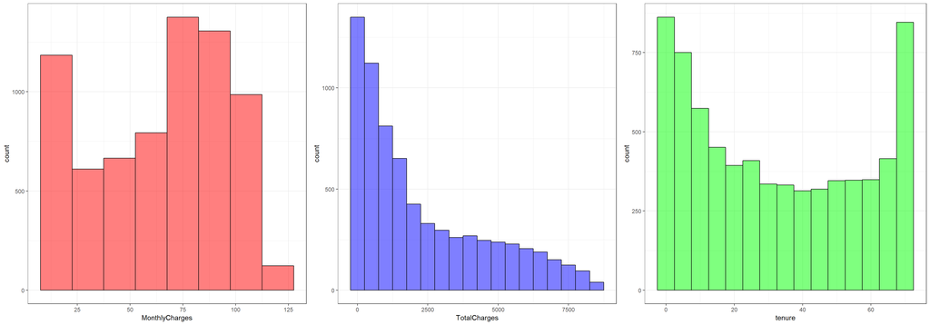

```r
a = ggplot(df, aes(MonthlyCharges)) +
    geom_histogram(color = "black", fill = "red", binwidth = 15, alpha = 0.5) +
    theme_bw()

b = ggplot(df, aes(TotalCharges)) +
    geom_histogram(color = "black", fill = "blue", alpha = 0.5, binwidth = 500) +
    theme_bw()

c = ggplot(df, aes(tenure)) +
    geom_histogram(color = "black", fill = "green", alpha = 0.5, binwidth = 5) +
    theme_bw()

grid.arrange(a, b, c, ncol=3)
```

The below chart shows the averages Total Monthly Charges by Tenure and Contract.  
As we can see Month to Month and one Year contract have a strong linear corralation . For the two year Contract There is a strong linear corralation but is not as strong as the other two contracts. As the tenure months increase the average monthly charges tends to increase as well.

The boxplot shows that the average for monthly charges are closed for being equal. We can use analysis of anavo to test the hypothesis that the mean are equal for the contracts.  
Boxplot are also used to detect outliers from the boxplot below it appears that there aren’t any visible outliers. I will perform a statistical analysis for outlier detection.

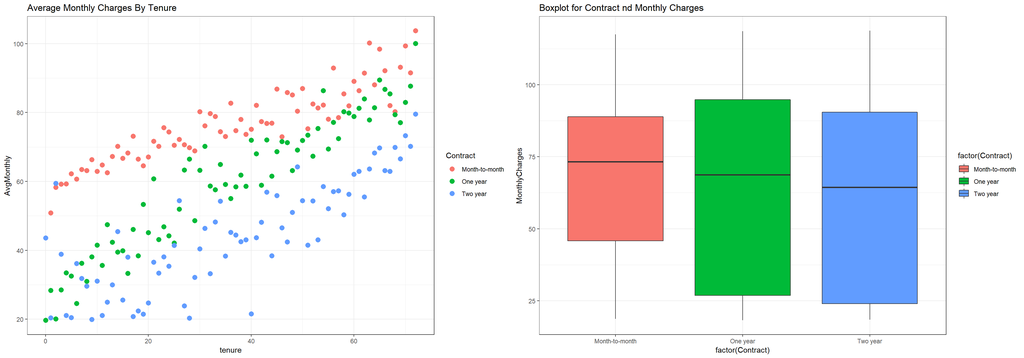

```r
d = df %>% group_by(Contract, tenure) %>%
    summarise(AvgMonthly = mean(MonthlyCharges)) %>%
    ggplot(aes(tenure, AvgMonthly, color = Contract)) + #, group = Contract)) +
    geom_point(size=3) +
    ggtitle("Average Monthly Charges By Tenure") +
    theme_bw()

e = ggplot(df, aes(factor(Contract), MonthlyCharges, fill = factor(Contract))) +
    geom_boxplot() +
    theme_bw() +
    ggtitle("Boxplot for Contract nd Monthly Charges")

grid.arrange(d, e, ncol = 2)
```

## Data Cleansing

Data cleansing is a big part in any data analytics project. The cleansing will allow us to standardize the data and prepare the data for modeling.  
we have noticed that the there are several features that contains the following:

- No Internet Service
- No Phone Service

These features contains other data such as Yes and No, We will normalize the data to just have a Yes and no. the below loop will look for those feature and transform them.

To explain the below code and what the code is doing to clean the data. the First block of code Loops through the dataset columns, then checks which features are factors. There are 7 columns that contains the following values:

- No internet service
- No phone service

For these columns that contains these data values I am converting them to “NO”.

For the second block of code during the loop I am finding the where there is a 2 factor level recoding these values to 0, 1.

The Total Charges contains 11 records with null values therefore I used the mean of the columns to impute the missing values.

Recorded the values for the column Contract.

For our model I will be scaling the continous variables. This will improved our model accuracy.

```r
for (i in names(df)) {
    if (is.factor(df[, i]) == TRUE) {
        df[, i] = as.factor(ifelse(as.character(df[, i]) == "No internet service" | as.character(df[, i]) == "No phone service", "No", as.character(df[, i])))

    }
    if (is.factor(df[, i]) & nlevels(df[, i]) == 2) {
        if (i == "gender") {
            df[, i] = factor(df[, i], levels = c("Female", "Male"), labels = c(0, 1))
        } else {
            df[, i] = factor(df[, i], levels = c("No", "Yes"), labels = c(0, 1))
        }
    }
}

df$TotalCharges = ifelse(is.na(df$TotalCharges), mean(df$TotalCharges, na.rm = TRUE), df$TotalCharges)

df$InternetService = factor(df$InternetService,
                            levels = c("DSL", "Fiber optic", "No"),
                            labels = c(1, 2, 3))

df$Contract = factor(df$Contract,
                     levels = c("Month-to-month", "One year", "Two year"),
                     labels = c(1, 2, 3))


for (i in colnames(df)) {
    if (is.numeric(df[, i]) & i != "SeniorCitizen") {
        df[, i] = scale(df[, i])
    }
}

summary(df)
```

```
##       customerID   gender   SeniorCitizen    Partner  Dependents
##  0002-ORFBO:   1   0:3488   Min.   :0.0000   0:3641   0:4933
##  0003-MKNFE:   1   1:3555   1st Qu.:0.0000   1:3402   1:2110
##  0004-TLHLJ:   1            Median :0.0000
##  0011-IGKFF:   1            Mean   :0.1621
##  0013-EXCHZ:   1            3rd Qu.:0.0000
##  0013-MHZWF:   1            Max.   :1.0000
##  (Other)   :7037
##       tenure.V1       PhoneService MultipleLines InternetService
##  Min.   :-1.3180714   0: 682       0:4072        1:2421
##  1st Qu.:-0.9516141   1:6361       1:2971        2:3096
##  Median :-0.1372647                              3:1526
##  Mean   : 0.0000000
##  3rd Qu.: 0.9213896
##  Max.   : 1.6135867
##
##  OnlineSecurity OnlineBackup DeviceProtection TechSupport StreamingTV
##  0:5024         0:4614       0:4621           0:4999      0:4336
##  1:2019         1:2429       1:2422           1:2044      1:2707
##
##
##
##
##
##  StreamingMovies Contract PaperlessBilling
##  0:4311          1:3875   0:2872
##  1:2732          2:1473   1:4171
##                  3:1695
##
##
##
##
##                    PaymentMethod   MonthlyCharges.V1
##  Bank transfer (automatic):1544   Min.   :-1.5457501
##  Credit card (automatic)  :1522   1st Qu.:-0.9724708
##  Electronic check         :2365   Median : 0.1857195
##  Mailed check             :1612   Mean   : 0.0000000
##                                   3rd Qu.: 0.8337743
##                                   Max.   : 1.7942248
##
##    TotalCharges.V1    Churn
##  Min.   :-0.9997793   0:5174
##  1st Qu.:-0.8304968   1:1869
##  Median :-0.3897352
##  Mean   : 0.0000000
##  3rd Qu.: 0.6637083
##  Max.   : 2.8262688
##
```

```r
final = df %>% select(-customerID, - PaymentMethod)
```

## Model Building

Before we begin the modeling process we need to do split the data into train and test.

We will use the train data to train our model and the the test data to test our model performance. I will use 80% of the data to train the model and 20% to test the model.

```r
#split train to test
split = sample.split(final$Churn, SplitRatio = 0.80)
train = subset(final, split == TRUE)
test = subset(final, split == FALSE)
```

```r
kable(head(train)) %>% kable_styling(bootstrap_options = "striped",
                full_width = F) %>%
                scroll_box(width = '100%')
```

|  | gender | SeniorCitizen | Partner | Dependents | tenure | PhoneService | MultipleLines | InternetService | OnlineSecurity | OnlineBackup | DeviceProtection | TechSupport | StreamingTV | StreamingMovies | Contract | PaperlessBilling | MonthlyCharges | TotalCharges | Churn |
| --- | --- | --- | --- | --- | --- | --- | --- | --- | --- | --- | --- | --- | --- | --- | --- | --- | --- | --- | --- |
| 3 | 1 | 0 | 0 | 0 | -1.2366364 | 1 | 0 | 1 | 1 | 1 | 0 | 0 | 0 | 0 | 1 | 1 | -0.3626346 | -0.9603312 | 1 |
| 4 | 1 | 0 | 0 | 0 | 0.5142149 | 0 | 0 | 1 | 1 | 0 | 1 | 1 | 0 | 0 | 2 | 0 | -0.7464825 | -0.1953865 | 0 |
| 5 | 0 | 0 | 0 | 0 | -1.2366364 | 1 | 0 | 2 | 0 | 0 | 0 | 0 | 0 | 0 | 1 | 1 | 0.1973512 | -0.9411259 | 1 |
| 6 | 0 | 0 | 0 | 0 | -0.9923316 | 1 | 1 | 2 | 0 | 0 | 1 | 0 | 1 | 1 | 1 | 1 | 1.1594634 | -0.6458279 | 1 |
| 7 | 1 | 0 | 0 | 1 | -0.4222870 | 1 | 1 | 2 | 0 | 1 | 0 | 0 | 1 | 0 | 1 | 1 | 0.8088491 | -0.1474174 | 0 |
| 8 | 0 | 0 | 0 | 0 | -0.9108966 | 0 | 0 | 1 | 1 | 0 | 0 | 0 | 0 | 0 | 1 | 0 | -1.1635639 | -0.8747904 | 0 |

```r
kable(head(test)) %>% kable_styling(bootstrap_options = "striped",
                full_width = F) %>%
                scroll_box(width = '100%')
```

|  | gender | SeniorCitizen | Partner | Dependents | tenure | PhoneService | MultipleLines | InternetService | OnlineSecurity | OnlineBackup | DeviceProtection | TechSupport | StreamingTV | StreamingMovies | Contract | PaperlessBilling | MonthlyCharges | TotalCharges | Churn |
| --- | --- | --- | --- | --- | --- | --- | --- | --- | --- | --- | --- | --- | --- | --- | --- | --- | --- | --- | --- |
| 1 | 0 | 0 | 1 | 0 | -1.27735389 | 0 | 0 | 1 | 0 | 1 | 0 | 0 | 0 | 0 | 1 | 1 | -1.1602405 | -0.9949007 | 0 |
| 2 | 1 | 0 | 0 | 0 | 0.06632271 | 1 | 0 | 1 | 1 | 0 | 1 | 0 | 0 | 0 | 2 | 0 | -0.2596105 | -0.1738633 | 0 |
| 14 | 1 | 0 | 0 | 0 | 0.67708480 | 1 | 1 | 2 | 0 | 1 | 1 | 0 | 1 | 1 | 1 | 1 | 1.2940594 | 1.2154522 | 1 |
| 44 | 0 | 0 | 0 | 0 | 1.24712942 | 1 | 1 | 1 | 1 | 1 | 1 | 1 | 1 | 0 | 3 | 1 | 0.5014385 | 1.1382557 | 0 |
| 45 | 0 | 0 | 1 | 0 | -0.78874422 | 1 | 1 | 1 | 1 | 1 | 0 | 1 | 1 | 0 | 1 | 1 | 0.3801359 | -0.5747683 | 0 |
| 60 | 0 | 0 | 0 | 0 | 1.61358668 | 1 | 1 | 2 | 0 | 0 | 1 | 1 | 1 | 1 | 3 | 1 | 1.4203470 | 2.4593373 | 0 |